# CPFMove Introduction

Philip Bertrand, PhD Candidate - SEAPOP & Norwegian Polar Institute

2020-10-09

[figure not shown]

> 1. Facilitating the delineation of trip from raw GPS data for CPF species
> 2. Offering basic tools for filtering/enhancing the quality of the trips
> 3. Offering basic diagnostic tools for parameter selection
> 4. Offering a basic plotting function to visually assessed the reliability of delineated tracks

## Data Format

The algortihm rely on a local metadata file that contains the information necessary to accurately delineating trips. Nine arguments are necessary for delineating trips (see below). Although this information is mandatory, the algorithm is flexible in regards of column’s names and can be specified accordingly in the main function

- **Clongitude**: The colony longitude (WGS84)
- **Clatitude**: The colony latitude (WGS84)
- **MetalRing**: The unique identifier of the captured bird
- **GPSType**: The type of GPS used
- **FIX**: The programmed sampling interval of the GPS
- **Deployment**: The standardized deployment date
- **Recapture**: The standardized recapture date
- **UTC_Deployment**: Standardized time of the deployment (UTC recommended)
- **UTC_Retrieval**: Standardized time of the recapture (UTC recommended)

```r
head(metafile)
```

```
##   Colony Clongitude Clatitude  Year MetalRing GPSType FIX Deployment  Recapture
## 1    OBS   12.28246  78.93942 GPS17   6234054  Catlog   2 2017-07-27 2017-07-29
## 2    OSS   12.44365  78.92961 GPS17   6234065   IGotU   2 2017-07-28 2017-07-30
## 3    OBS   12.28246  78.93942 GPS18   6228840   IGotU  10 2018-06-27 2018-06-30
## 4    OSS   12.44365  78.92961 GPS18   6228779   IGotU  10 2018-06-28 2018-07-01
## 5    OSS   12.44365  78.92961 GPS18   6228876   IGotU   2 2018-07-11 2018-07-17
## 6    OBS   12.28246  78.93942 GPS18   6228776   IGotU   2 2018-07-13 2018-07-15
##   UTC_Deployment UTC_Retrieval
## 1          11:29         13:20
## 2          12:36         13:40
## 3          15:10         11:31
## 4          11:23         12:50
## 5          11:05         09:43
## 6          10:51         11:53
```

## Trip Delineation

Trip delineation is performed via the `filt()` function. The function has many arguments which among those, 5 has filtering effect (see `?filt()` for the corresponding details);

The main purpose of this package is to facilitate the delineation of foraging trips from raw GPS data.Trip delineation is however a relatively flexible procedure and rely essentially on how we define “spatially” the colony.

The colony radius is the main parameter for delineation (see **BuffColony**). In other words, this treshold (km) is used to build an area around the colony’s centroid. From that area, all locations falling inside will be categorized as *colony* locations and those falling outside as *trip* ones. This binary category will thereafter be used for segmenting each foraging trip, *i.e.* having the last point in the colony before departure and the first point at the colony at arrival

### Investigating effect of filtering options

The **BuffColony** argument have an important effect on the resulting trip dataset. This package has one function for investigating such effect.

> SensCol()

This is a bootstrap function for estimating the variation within and among customized scenarios. Here, scenarios are a sequence of buffer radii (km). These normally described a decaying function of the number of final trips along increment of the radius size of the colony and the minimal duration that a trip should have. The second rate of change is also computed, among means of the different bootstrapping scenario. User can thus decide of a certain treshold to show where the variation among scenario “stabilize”. In this function (see below) **iter** correspond to the number of bootsrap iterations

```r
param <- seq(0.05, 1, by = 0.05) ## Radii in kilometers

sc <- sensCol(pathF, pathM, metname, timezone, iter = 300, param = param, speedTresh = 90,
          gpst = "GPSType", ddep = "deployment", drecap = "recapture", colony = "colony",
          year = "year", ring = "ring", FIX = "FIX", tdep = "utc_deployment", trecap = "utc_retrieval",
          FixInt = 2, Interpolate = T)
```

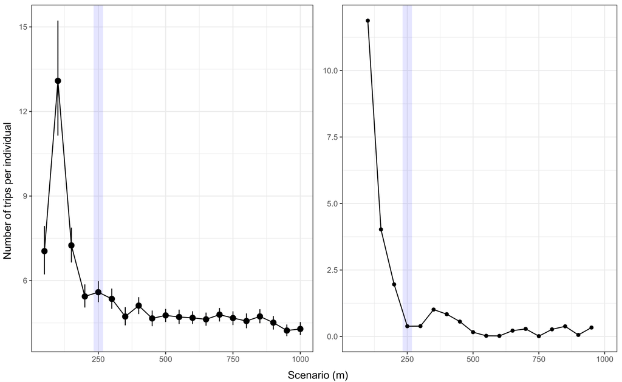

Parameters selection is highly dependable of the species under investigation and its relative behavior. The function has in total 5 filtering options, which will impact to a varying extent the final outputs:

- Speed filtering is available (see **speedTresh**) and will remove locations associated to a upper speed level. The function use the function developped by Freitas *et al.* 2008 from the package “argosfilter”. This function is itself based on the approach suggested by McConnell *et al.* 2002, except in case where the relevant point is wihtin a distance of 5 km from the previous fix. See references in the `?filt()` documentation
- One can filterate trip as function of the number of points generated after interpolation. In other words, many tracks have many missing points and a tracks composed from 90% interpolatde points might not have the same representativity than another one that have only 10%. This function let user to disciminate based on a certain treshold (see **filtNA**)
- Minimum trip length is a parameter to filterate very small trips, corresponding to bathing trip, resting at some distance of the colony or visiting neighbors. This parameter is in minutes (see **MinTripDur**). Another function, named `SensTime()` works the same as the `SensCol()` but aims to evaluate the sensitivity of the results as function of different minimum time thresold that a trip should have. See `?SensTime()` for more details

#### Filtering example

One could also based his/her filtering parameterization based on the frequency histograms. In the case of the *filtNA* argument, one could set **filtNA = 1** and run;

```r
f <- filt(pathF, pathM, metname, timezone, speedTresh = 90, gpst = "GPSType",
        ddep = "deployment", drecap = "recapture", colony = "colony", year = "year",
        ring = "ring", FIX = "FIX", tdep = "utc_deployment", trecap = "utc_retrieval",
        BuffColony = 0.25, MinTripDur = 30, Complete = T, FixInt = 2,
        Interpolate = T, filtNA = 1, metINFO = c("ring", "year", "species", "colony"), splt = F)
```

this function will give the following object;

```r
head(f)
```

```
##                datetime Latitude Longitude                     trackID nbNA
## 619 2017-07-04 10:29:32 74.34928  19.09229 2017_MRK_6177598_2017-07-06    0
## 620 2017-07-04 10:31:32 74.35087  19.09306 2017_MRK_6177598_2017-07-06    0
## 621 2017-07-04 10:33:32 74.36522  19.05411 2017_MRK_6177598_2017-07-06    1
## 622 2017-07-04 10:35:32 74.38340  19.01465 2017_MRK_6177598_2017-07-06    0
## 623 2017-07-04 10:37:32 74.38385  19.01490 2017_MRK_6177598_2017-07-06    0
## 624 2017-07-04 10:39:32 74.38540  19.02510 2017_MRK_6177598_2017-07-06    0
##     ColonyDist  PointDist TimeElapsed      Speed ColonyorTrip tripID
## 619  0.0000000 0.04604938         120  0.3837448       colony     11
## 620  0.2656363 0.17897889         120  1.4914907         trip     11
## 621  2.2050493 1.98556201         120 16.5463501         trip     11
## 622  4.5551192 2.35066068         120 19.5888390         trip     11
## 623  4.5936811 0.05004899         120  0.4170749         trip     11
## 624  4.5990650 0.35208534         120  2.9340445         trip     11
##                           birdTrip TripLength TripDist nPoints  maxDist
## 619 2017_MRK_6177598_2017-07-06_11       2630 733.2717    1316 284.0867
## 620 2017_MRK_6177598_2017-07-06_11       2630 733.2717    1316 284.0867
## 621 2017_MRK_6177598_2017-07-06_11       2630 733.2717    1316 284.0867
## 622 2017_MRK_6177598_2017-07-06_11       2630 733.2717    1316 284.0867
## 623 2017_MRK_6177598_2017-07-06_11       2630 733.2717    1316 284.0867
## 624 2017_MRK_6177598_2017-07-06_11       2630 733.2717    1316 284.0867
##        propNA BegPoint EndPoint    ring year species colony  ColLong   ColLat
## 619 0.1854103   colony   colony 6177598 2017   rissa    MRK 19.09303 74.34849
## 620 0.1854103   colony   colony 6177598 2017   rissa    MRK 19.09303 74.34849
## 621 0.1854103   colony   colony 6177598 2017   rissa    MRK 19.09303 74.34849
## 622 0.1854103   colony   colony 6177598 2017   rissa    MRK 19.09303 74.34849
## 623 0.1854103   colony   colony 6177598 2017   rissa    MRK 19.09303 74.34849
## 624 0.1854103   colony   colony 6177598 2017   rissa    MRK 19.09303 74.34849
```

make sure to consider only one value per trip (and not all locations);

```r
df <- as.data.frame(f[!duplicated(f$birdTrip),])
```

and then;

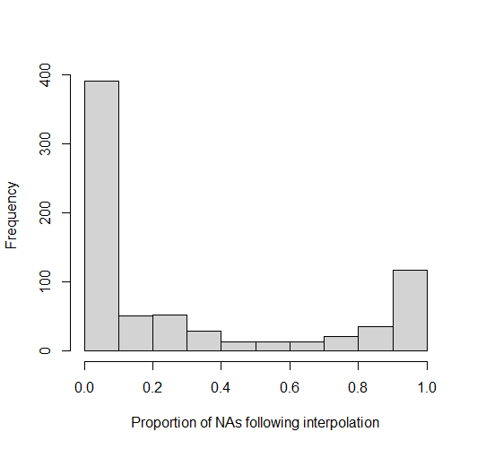

```r
hist(df$propNA, main ="", xlab="Proportion of NAs following interpolation")
```

whereas the y-axis represent the number of unique trips in the dataset. From that figure, one could thus decide of the appropriate “arbitrarily” treshold to consider (*e.g.* using **filtNA = 0.8** would remove all trips that have a proportion of NAs => 0.8)

Finally, on can also filterate as function of the completeness of the tracks (see **Complete**). Depending of the question and data representation, one could decide to only use complete trips for his/her analyses Interpolation is executed by `adehabitatLT::redisltraj()`. If you want to add additional data to the final objects, these one needs to could be easily attached from the metadata, using the `metINFO = c(“ring”, “year”, “colony”)` argument The option splt let you split the final object into an array instead of a data frame. In case the **splt** is set to **TRUE**, the object can be unsplitted thereafter using `do.call(rbind, object)`

The script has now produced one object containing the segmented trips. One way to visualize those trips is to pass them into the `plottingMAP()` function;

## Plotting the delineated trips

Using the previous object from the `filt()` function, the `plottingMAP()` function plots each trip, along with the colony and the trip’s locations (*blue = colony; purple = trip locations*). The function use the `basemap()` from the [ggOceanMaps](https://mikkovihtakari.github.io/ggOceanMaps/) package in its pipeline. If mulitple trips are given, the function will make one figure per trip

A path should first be declared, for instance;

```r
path <- c("C:/Users/Desktop/map")
```

The following script codes now for plotting only the first bird from the splitted object (see **splt** object from the `filt()`);

```r
plotMAP(f[1], pmap = F, path = path, ColLong = f[1]$ColLong, ColLat = f[1]$ColLat)
```

Giving the following output;

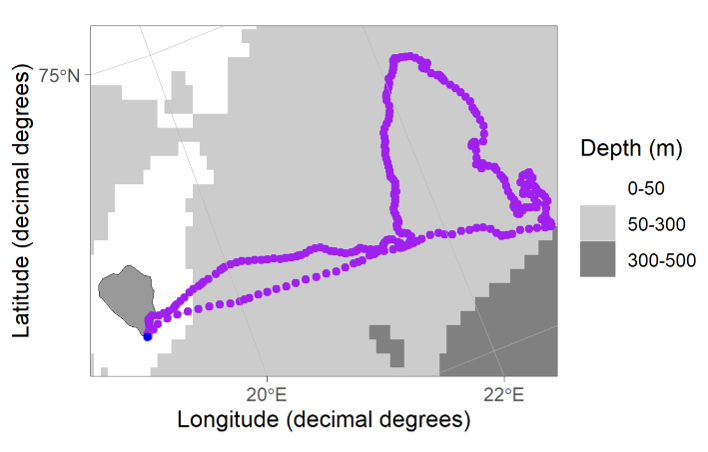